# W3cubDocs

/TensorFlow Guide

# TensorFlow Debugger

[`tfdbg`](https://www.tensorflow.org/api_docs/python/tfdbg) is a specialized debugger for TensorFlow. It lets you view the internal structure and states of running TensorFlow graphs during training and inference, which is difficult to debug with general-purpose debuggers such as Python's `pdb` due to TensorFlow's computation-graph paradigm.

This guide focuses on the command-line interface (CLI) of [`tfdbg`](https://www.tensorflow.org/api_docs/python/tfdbg). For guide on how to use the graphical user interface (GUI) of tfdbg, i.e., the **TensorBoard Debugger Plugin**, please visit [its README](https://github.com/tensorflow/tensorboard/blob/master/tensorboard/plugins/debugger/README.md).

> **Note:** The TensorFlow debugger uses a curses-based text user interface. On Mac OS X, the `ncurses` library is required and can be installed with `brew install homebrew/dupes/ncurses`. On Windows, curses isn't as well supported, so a [readline](https://en.wikipedia.org/wiki/GNU_Readline)-based interface can be used with tfdbg by installing `pyreadline` with `pip`. If you use Anaconda3, you can install it with a command such as `"C:\Program Files\Anaconda3\Scripts\pip.exe" install pyreadline`. Unofficial Windows curses packages can be downloaded [here](https://www.lfd.uci.edu/~gohlke/pythonlibs/#curses), then subsequently installed using `pip install <your_version>.whl`, however curses on Windows may not work as reliably as curses on Linux or Mac.

This tutorial demonstrates how to use the **tfdbg** CLI to debug the appearance of [`nan`s](https://en.wikipedia.org/wiki/NaN) and [`inf`s](https://en.wikipedia.org/wiki/Infinity), a frequently-encountered type of bug in TensorFlow model development. The following example is for users who use the low-level [`Session`](https://www.tensorflow.org/api_docs/python/tf/Session) API of TensorFlow. A later section of this document describes how to use **tfdbg** with a higher-level API, namely tf-learn `Estimator`s and `Experiment`s. To *observe* such an issue, run the following command without the debugger (the source code can be found [here](https://github.com/tensorflow/tensorflow/blob/master/tensorflow/python/debug/examples/debug_mnist.py)):

```
python -m tensorflow.python.debug.examples.debug_mnist
```

This code trains a simple neural network for MNIST digit image recognition. Notice that the accuracy increases slightly after the first training step, but then gets stuck at a low (near-chance) level:

```
Accuracy at step 0: 0.1113
Accuracy at step 1: 0.3183
Accuracy at step 2: 0.098
Accuracy at step 3: 0.098
Accuracy at step 4: 0.098
```

Wondering what might have gone wrong, you suspect that certain nodes in the training graph generated bad numeric values such as `inf`s and `nan`s, because this is a common cause of this type of training failure. Let's use tfdbg to debug this issue and pinpoint the exact graph node where this numeric problem first surfaced.

## Wrapping TensorFlow Sessions with tfdbg

To add support for tfdbg in our example, all that is needed is to add the following lines of code and wrap the Session object with a debugger wrapper. This code is already added in debug_mnist.py, so you can activate tfdbg CLI with the `--debug` flag at the command line.

```python
# Let your BUILD target depend on "//tensorflow/python/debug:debug_py"
# (You don't need to worry about the BUILD dependency if you are using a pip
#  install of open-source TensorFlow.)
from tensorflow.python import debug as tf_debug

sess = tf_debug.LocalCLIDebugWrapperSession(sess)
```

This wrapper has the same interface as Session, so enabling debugging requires no other changes to the code. The wrapper provides additional features, including:

- Bringing up a CLI before and after `Session.run()` calls, to let you control the execution and inspect the graph's internal state.
- Allowing you to register special `filters` for tensor values, to facilitate the diagnosis of issues.

In this example, we have already registered a tensor filter called [`tfdbg.has_inf_or_nan`](https://www.tensorflow.org/api_docs/python/tfdbg/has_inf_or_nan), which simply determines if there are any `nan` or `inf` values in any intermediate tensors (tensors that are neither inputs or outputs of the `Session.run()` call, but are in the path leading from the inputs to the outputs). This filter is for `nan`s and `inf`s is a common enough use case that we ship it with the [`debug_data`](https://www.tensorflow.org/api_guides/python/tfdbg#Classes_for_debug_dump_data_and_directories) module.

> **Note:** You can also write your own custom filters. See the [API documentation](https://www.tensorflow.org/api_docs/python/tfdbg/DebugDumpDir#find) of `DebugDumpDir.find()` for additional information.

## Debugging Model Training with tfdbg

Let's try training the model again, but with the `--debug` flag added this time:

```
python -m tensorflow.python.debug.examples.debug_mnist --debug
```

The debug wrapper session will prompt you when it is about to execute the first `Session.run()` call, with information regarding the fetched tensor and feed dictionaries displayed on the screen.

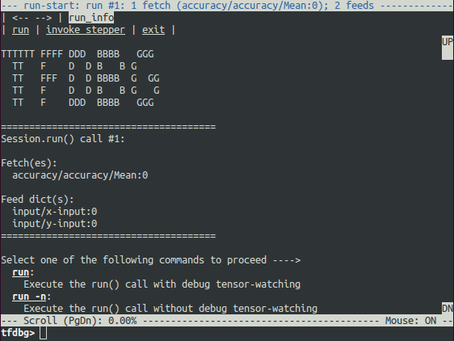

This is what we refer to as the *run-start CLI*. It lists the feeds and fetches to the current `Session.run` call, before executing anything.

If the screen size is too small to display the content of the message in its entirety, you can resize it.

Use the **PageUp** / **PageDown** / **Home** / **End** keys to navigate the screen output. On most keyboards lacking those keys **Fn + Up** / **Fn + Down** / **Fn + Right** / **Fn + Left** will work.

Enter the `run` command (or just `r`) at the command prompt:

```
tfdbg> run
```

The `run` command causes tfdbg to execute until the end of the next `Session.run()` call, which calculates the model's accuracy using a test data set. tfdbg augments the runtime Graph to dump all intermediate tensors. After the run ends, tfdbg displays all the dumped tensors values in the *run-end CLI*. For example:

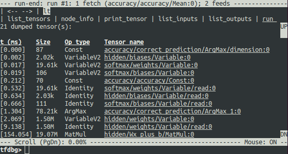

This list of tensors can also be obtained by running the command `lt` after you executed `run`.

### tfdbg CLI Frequently-Used Commands

Try the following commands at the `tfdbg>` prompt (referencing the code at `tensorflow/python/debug/examples/debug_mnist.py`):

| Command | Syntax or Option | Explanation | Example |
| --- | --- | --- | --- |
| **`lt`** |  | **List dumped tensors.** | `lt` |
|  | `-n <name_pattern>` | List dumped tensors with names matching given regular-expression pattern. | `lt -n Softmax.*` |
|  | `-t <op_pattern>` | List dumped tensors with op types matching given regular-expression pattern. | `lt -t MatMul` |
|  | `-f <filter_name>` | List only the tensors that pass a registered tensor filter. | `lt -f has_inf_or_nan` |
|  | `-f <filter_name> -fenn <regex>` | List only the tensors that pass a registered tensor filter, excluding nodes with names matching the regular expression. | `lt -f has_inf_or_nan` `-fenn .*Sqrt.*` |
|  | `-s <sort_key>` | Sort the output by given `sort_key`, whose possible values are `timestamp` (default), `dump_size`, `op_type` and `tensor_name`. | `lt -s dump_size` |
|  | `-r` | Sort in reverse order. | `lt -r -s dump_size` |
| **`pt`** |  | **Print value of a dumped tensor.** |  |
|  | `pt <tensor>` | Print tensor value. | `pt hidden/Relu:0` |
|  | `pt <tensor>[slicing]` | Print a subarray of tensor, using [numpy](http://www.numpy.org/)-style array slicing. | `pt hidden/Relu:0[0:50,:]` |
|  | `-a` | Print the entirety of a large tensor, without using ellipses. (May take a long time for large tensors.) | `pt -a hidden/Relu:0[0:50,:]` |
|  | `-r <range>` | Highlight elements falling into specified numerical range. Multiple ranges can be used in conjunction. | `pt hidden/Relu:0 -a -r [[-inf,-1],[1,inf]]` |
|  | `-n <number>` | Print dump corresponding to specified 0-based dump number. Required for tensors with multiple dumps. | `pt -n 0 hidden/Relu:0` |
|  | `-s` | Include a summary of the numeric values of the tensor (applicable only to non-empty tensors with Boolean and numeric types such as `int*` and `float*`.) | `pt -s hidden/Relu:0[0:50,:]` |
|  | `-w` | Write the value of the tensor (possibly sliced) to a Numpy file using [`numpy.save()`](https://docs.scipy.org/doc/numpy-1.13.0/reference/generated/numpy.save.html) | `pt -s hidden/Relu:0 -w /tmp/relu.npy` |
| **`@[coordinates]`** |  | Navigate to specified element in `pt` output. | `@[10,0]` or `@10,0` |
| **`/regex`** |  | less-style search for given regular expression. | `/inf` |
| **`/`** |  | Scroll to the next line with matches to the searched regex (if any). | `/` |
| **`pf`** |  | **Print a value in the feed_dict to `Session.run`.** |  |
|  | `pf <feed_tensor_name>` | Print the value of the feed. Also note that the `pf` command has the `-a`, `-r` and `-s` flags (not listed below), which have the same syntax and semantics as the identically-named flags of `pt`. | `pf input_xs:0` |
| **eval** |  | **Evaluate arbitrary Python and numpy expression.** |  |
|  | `eval <expression>` | Evaluate a Python / numpy expression, with numpy available as `np` and debug tensor names enclosed in backticks. | `` eval "np.matmul((`output/Identity:0` / `Softmax:0`).T, `Softmax:0`)" `` |
|  | `-a` | Print a large-sized evaluation result in its entirety, i.e., without using ellipses. | `` eval -a 'np.sum(`Softmax:0`, axis=1)' `` |
|  | `-w` | Write the result of the evaluation to a Numpy file using [`numpy.save()`](https://docs.scipy.org/doc/numpy-1.13.0/reference/generated/numpy.save.html) | `` eval -a 'np.sum(`Softmax:0`, axis=1)' -w /tmp/softmax_sum.npy `` |
| **`ni`** |  | **Display node information.** |  |
|  | `-a` | Include node attributes in the output. | `ni -a hidden/Relu` |
|  | `-d` | List the debug dumps available from the node. | `ni -d hidden/Relu` |
|  | `-t` | Display the Python stack trace of the node's creation. | `ni -t hidden/Relu` |
| **`li`** |  | **List inputs to node** |  |
|  | `-r` | List the inputs to node, recursively (the input tree.) | `li -r hidden/Relu:0` |
|  | `-d <max_depth>` | Limit recursion depth under the `-r` mode. | `li -r -d 3 hidden/Relu:0` |
|  | `-c` | Include control inputs. | `li -c -r hidden/Relu:0` |
|  | `-t` | Show op types of input nodes. | `li -t -r hidden/Relu:0` |
| **`lo`** |  | **List output recipients of node** |  |
|  | `-r` | List the output recipients of node, recursively (the output tree.) | `lo -r hidden/Relu:0` |
|  | `-d <max_depth>` | Limit recursion depth under the `-r` mode. | `lo -r -d 3 hidden/Relu:0` |
|  | `-c` | Include recipients via control edges. | `lo -c -r hidden/Relu:0` |
|  | `-t` | Show op types of recipient nodes. | `lo -t -r hidden/Relu:0` |
| **`ls`** |  | **List Python source files involved in node creation.** |  |
|  | `-p <path_pattern>` | Limit output to source files matching given regular-expression path pattern. | `ls -p .*debug_mnist.*` |
|  | `-n` | Limit output to node names matching given regular-expression pattern. | `ls -n Softmax.*` |
| **`ps`** |  | **Print Python source file.** |  |
|  | `ps <file_path>` | Print given Python source file source.py, with the lines annotated with the nodes created at each of them (if any). | `ps /path/to/source.py` |
|  | `-t` | Perform annotation with respect to Tensors, instead of the default, nodes. | `ps -t /path/to/source.py` |
|  | `-b <line_number>` | Annotate source.py beginning at given line. | `ps -b 30 /path/to/source.py` |
|  | `-m <max_elements>` | Limit the number of elements in the annotation for each line. | `ps -m 100 /path/to/source.py` |
| **`run`** |  | **Proceed to the next Session.run()** | `run` |
|  | `-n` | Execute through the next `Session.run` without debugging, and drop to CLI right before the run after that. | `run -n` |
|  | `-t <T>` | Execute `Session.run` `T - 1` times without debugging, followed by a run with debugging. Then drop to CLI right after the debugged run. | `run -t 10` |
|  | `-f <filter_name>` | Continue executing `Session.run` until any intermediate tensor triggers the specified Tensor filter (causes the filter to return `True`). | `run -f has_inf_or_nan` |
|  | `-f <filter_name> -fenn <regex>` | Continue executing `Session.run` until any intermediate tensor whose node names doesn't match the regular expression triggers the specified Tensor filter (causes the filter to return `True`). | `run -f has_inf_or_nan -fenn .*Sqrt.*` |
|  | `--node_name_filter <pattern>` | Execute the next `Session.run`, watching only nodes with names matching the given regular-expression pattern. | `run --node_name_filter Softmax.*` |
|  | `--op_type_filter <pattern>` | Execute the next `Session.run`, watching only nodes with op types matching the given regular-expression pattern. | `run --op_type_filter Variable.*` |
|  | `--tensor_dtype_filter <pattern>` | Execute the next `Session.run`, dumping only Tensors with data types (`dtype`s) matching the given regular-expression pattern. | `run --tensor_dtype_filter int.*` |
|  | `-p` | Execute the next `Session.run` call in profiling mode. | `run -p` |
| **`ri`** |  | **Display information about the run the current run, including fetches and feeds.** | `ri` |
| **`config`** |  | **Set or show persistent TFDBG UI configuration.** |  |
|  | `set` | Set the value of a config item: {`graph_recursion_depth`, `mouse_mode`}. | `config set graph_recursion_depth 3` |
|  | `show` | Show current persistent UI configuration. | `config show` |
| **`help`** |  | **Print general help information** | `help` |
|  | `help <command>` | Print help for given command. | `help lt` |

Note that each time you enter a command, a new screen output will appear. This is somewhat analogous to web pages in a browser. You can navigate between these screens by clicking the `<--` and `-->` text arrows near the top-left corner of the CLI.

### Other Features of the tfdbg CLI

In addition to the commands listed above, the tfdbg CLI provides the following additional features:

- To navigate through previous tfdbg commands, type in a few characters followed by the Up or Down arrow keys. tfdbg will show you the history of commands that started with those characters.
- To navigate through the history of screen outputs, do either of the following:
  - Use the `prev` and `next` commands.
  - Click underlined `<--` and `-->` links near the top left corner of the screen.
- Tab completion of commands and some command arguments.
- To redirect the screen output to a file instead of the screen, end the command with bash-style redirection. For example, the following command redirects the output of the pt command to the `/tmp/xent_value_slices.txt` file:

```
tfdbg> pt cross_entropy/Log:0[:, 0:10] > /tmp/xent_value_slices.txt
```

### Finding `nan`s and `inf`s

In this first `Session.run()` call, there happen to be no problematic numerical values. You can move on to the next run by using the command `run` or its shorthand `r`.

> TIP: If you enter `run` or `r` repeatedly, you will be able to move through the `Session.run()` calls in a sequential manner.

> You can also use the `-t` flag to move ahead a number of `Session.run()` calls at a time, for example:

> ```
> tfdbg> run -t 10
> ```

Instead of entering `run` repeatedly and manually searching for `nan`s and `inf`s in the run-end UI after every `Session.run()` call (for example, by using the `pt` command shown in the table above) , you can use the following command to let the debugger repeatedly execute `Session.run()` calls without stopping at the run-start or run-end prompt, until the first `nan` or `inf` value shows up in the graph. This is analogous to *conditional breakpoints* in some procedural-language debuggers:

```
tfdbg> run -f has_inf_or_nan
```

> NOTE: The preceding command works properly because a tensor filter called `has_inf_or_nan` has been registered for you when the wrapped session is created. This filter detects `nan`s and `inf`s (as explained previously). If you have registered any other filters, you can use "run -f" to have tfdbg run until any tensor triggers that filter (cause the filter to return True).

> ```
> def my_filter_callable(datum, tensor):
>   # A filter that detects zero-valued scalars.
>   return len(tensor.shape) == 0 and tensor == 0.0
>
> sess.add_tensor_filter('my_filter', my_filter_callable)
> ```

> Then at the tfdbg run-start prompt run until your filter is triggered:

> ```
> tfdbg> run -f my_filter
> ```

See [this API document](https://www.tensorflow.org/api_docs/python/tfdbg/DebugDumpDir#find) for more information on the expected signature and return value of the predicate `Callable` used with `add_tensor_filter()`.

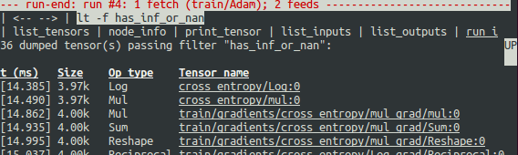

As the screen display indicates on the first line, the `has_inf_or_nan` filter is first triggered during the fourth `Session.run()` call: an [Adam optimizer](https://www.tensorflow.org/api_docs/python/tf/train/AdamOptimizer) forward-backward training pass on the graph. In this run, 36 (out of the total 95) intermediate tensors contain `nan` or `inf` values. These tensors are listed in chronological order, with their timestamps displayed on the left. At the top of the list, you can see the first tensor in which the bad numerical values first surfaced: `cross_entropy/Log:0`.

To view the value of the tensor, click the underlined tensor name `cross_entropy/Log:0` or enter the equivalent command:

```
tfdbg> pt cross_entropy/Log:0
```

Scroll down a little and you will notice some scattered `inf` values. If the instances of `inf` and `nan` are difficult to spot by eye, you can use the following command to perform a regex search and highlight the output:

```
tfdbg> /inf
```

Or, alternatively:

```
tfdbg> /(inf|nan)
```

You can also use the `-s` or `--numeric_summary` command to get a quick summary of the types of numeric values in the tensor:

```
tfdbg> pt -s cross_entropy/Log:0
```

From the summary, you can see that several of the 1000 elements of the `cross_entropy/Log:0` tensor are `-inf`s (negative infinities).

Why did these infinities appear? To further debug, display more information about the node `cross_entropy/Log` by clicking the underlined `node_info` menu item on the top or entering the equivalent node_info (`ni`) command:

```
tfdbg> ni cross_entropy/Log
```

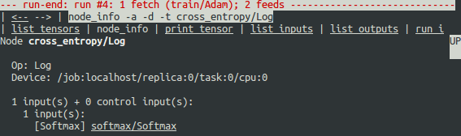

[output not shown]

Examine the values in the input tensor, searching for zeros:

```
tfdbg> /0\.000
```

Indeed, there are zeros. Now it is clear that the origin of the bad numerical values is the node `cross_entropy/Log` taking logs of zeros. To find out the culprit line in the Python source code, use the `-t` flag of the `ni` command to show the traceback of the node's construction:

```
tfdbg> ni -t cross_entropy/Log
```

If you click "node_info" at the top of the screen, tfdbg automatically shows the traceback of the node's construction.

From the traceback, you can see that the op is constructed at the following line: [`debug_mnist.py`](https://www.github.com/tensorflow/tensorflow/blob/r1.8/tensorflow/python/debug/examples/debug_mnist.py):

```python
diff = y_ * tf.log(y)
```

**tfdbg** has a feature that makes it easy to trace Tensors and ops back to lines in Python source files. It can annotate lines of a Python file with the ops or Tensors created by them. To use this feature, simply click the underlined line numbers in the stack trace output of the `ni -t <op_name>` commands, or use the `ps` (or `print_source`) command such as: `ps /path/to/source.py`. For example, the following screenshot shows the output of a `ps` command.

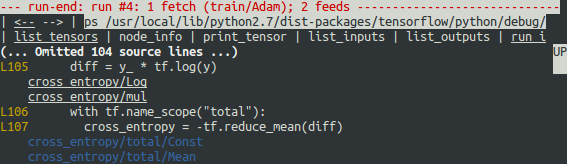